### Do Pornography Consumption Patterns Change Over Ramadan in Muslim Countries?

While pornography is always forbidden in Islam, this is even more true over the month of Ramadan. The message of Ramadan emphasizes pious behaviors and abstaining from physical pleasures: specifically, sex, food and water during the daylight hours. Many Muslims increase their religious observance over this time-period through fasting and attending mosque and religious authorities [encourage](http://seekershub.org/ans-blog/2009/09/12/does-looking-at-pornography-break-ones-fast/) their followers eliminate pornography viewing. All the while, many Muslim-majority countries are fighting [a losing battle](https://www.salon.com/2015/01/15/why_porn_is_exploding_in_the_middle_east_partner/) against rising consumption of pornography in their countries, with numerous governments attempting and failing to enforce internet porn bans.

#### My hypothesis is that Ramadan could enact a negative or positive impact on pornography viewing by Muslims.

On the one hand, pornography viewing might be expected to decrease over Ramadan as individuals increase their religious observance and become occupied with family holiday celebrations. On the other hand, given that Ramadan is often marked by shorter work or school day in Muslim countries, people might gain more free time to search for pornography.

There has been conflicting research connecting pornography searching to religious observance and holidays. A selection of studies coducted at the individual level show that religious individuals report lower levels of pornography consumption. [Kyler Rasmussen, Alex Bierman. (2016)](https://doi.org/10.1016/j.adolescence.2016.03.017.) However, a study which employed data from google searches and web subscriptions showed the opposite. In a U.S. based study of google search data, higher percentages of practicing Christians in a state were shown to predict higher frequencies of porn searching.[(Andrew L. Whitehead & Samuel L. Perry 2018)](https://www.ncbi.nlm.nih.gov/pubmed/28276941) Another study also showed that regions where more people report regularly attending religious services purchased the same total level of porn but had a smaller portion of subscriptions beginning on Sunday. [Edelman, B. (2009)](http://www.benedelman.org/publications/redlightstates.pdf) Finally, [pornhub](https://www.pornhub.com/insights/christmas-holiday-searches) statistics from the holiday season demonstrate that traffic changes on Christmas Day vary widely by country. In some countries such as Australia, the U.K., and the Italy there is a decrease in traffic by over twenty percent. However, in Japan, India and Russia there is the opposite effect of an increase in traffic from two to thirteen percent on Christamas.

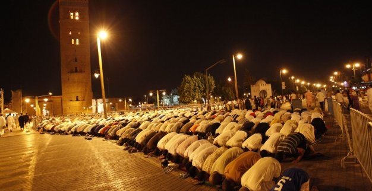

### My Analysis of Google Trends Data Reveals a Significant Decrease in Pornography Searching over Ramadan

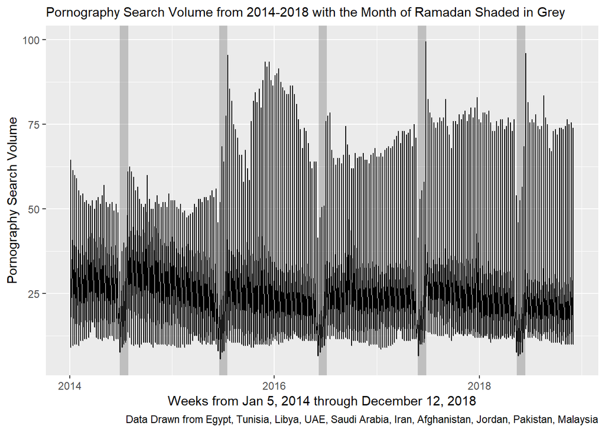

### How I compiled my data:

**Summary statistics**

| Statistic | Q1 | Q2 | mean |
| --- | --- | --- | --- |
| N | 2,827 | 2,827 | 2,827 |
| Mean | 36.2 | 32.3 | 34.2 |
| St. Dev. | 19.1 | 18.1 | 18.0 |
| Min | 6 | 2 | 6 |
| Pctl(25) | 20 | 17 | 18 |
| Pctl(75) | 49 | 42 | 45.5 |
| Max | 100 | 100 | 100 |

#### A note on interpreting Google Trends values:

• Each data point is divided by the total searches of the geography and time range it represents to compare relative popularity. Otherwise, places with the most search volume would always be ranked highest. • The resulting numbers are then scaled on a range of 0 to 100 based on a topic’s proportion to all searches on all topics. • Different regions that show the same search interest for a term don’t always have the same total search volumes. Source: [Google trends](https://support.google.com/trends/answer/4365533?hl=en&ref_topic=6248052)

#### Independent Variables:

“ **Presence of Ramadan** ” is a binary variable with values of one or zero based on the presence of absence of Ramadan.

“ **In Eid** ” is a categorical variable which registers the presence of Eid al-Futr. Eid al-Futr is a three-day feasting holiday which always occurs immediately following Ramadan. Thus, “In Eid” is also standing as an “after ramadan” variable.

“ **Week Before Ram** ” is a binary variable for the week before Ramadan. It examines whether individuals decrease their pornography searching in advance of the holiday.

*Controls: I include controls for year and country.

These results are significant (p < .01) and include controls for year and country.

**Changes in Sex and Porn Related Search Values Over Ramadan**

|  | *Dependent variable:* |  |  |  |
| --- | --- | --- | --- | --- |
|  | Mean values for ‘sex’ and ‘porn’ hits by Week |  |  |  |
|  | (1) | (2) | (3) | (4) |
| Week Before Ram (0 or 1) |  |  |  | -3.990*** |
|  |  |  |  | (0.832) |
| Presence of Ram (0 or 1) | -8.459*** | -8.379*** | -9.718*** | -6.465*** |
|  | (1.154) | (0.518) | (0.517) | (0.852) |
| Presence of Eid (0 or 1) |  |  | 16.806*** | 14.528*** |
|  |  |  | (1.406) | (1.479) |
| Constant | 35.004*** | 51.477*** | 51.282*** | 51.397*** |
|  | (0.353) | (0.584) | (0.570) | (0.568) |
| Controls for Country and Year? | No | Yes | Yes | Yes |
| Observations | 2,827 | 2,827 | 2,827 | 2,827 |
| R<sup>2</sup> | 0.019 | 0.804 | 0.813 | 0.815 |
| Adjusted R<sup>2</sup> | 0.018 | 0.803 | 0.812 | 0.814 |
| Residual Std. Error | 17.855 (df = 2825) | 8.002 (df = 2811) | 7.807 (df = 2810) | 7.777 (df = 2809) |
| F Statistic | 53.724*** (df = 1; 2825) | 768.039*** (df = 15; 2811) | 765.334*** (df = 16; 2810) | 727.298*** (df = 17; 2809) |
| *Note:* | p<0.1; p<0.05; p<0.01 |  |  |  |

### Why does Pornography Searching Decrease over the Ramadan Holiday?

Decreases in the popularity of porn over Ramadan may correspond to levels of individual religious observance. However, there could also be social and scheduling factors associated with observance of Ramadan, which would alter individual practice.Given that most pornography searches occur at night, schedule changes during Ramadan for late night family gatherings and breakfast meals and prayers coudld render a significant impact to internet browsing behaviors Moreover, many countries have Ramadan laws, which [criminalize](http://www.bbc.co.uk/religion/religions/islam/practices/ramadan_1.shtml) public acts of non-observance, this could include viewing porn in public settings such as internet cafes.Another factor could be the physical exhaustion from fasting decreases interest in sexual stimulation. Bio-chemical or neurological changes associated with fasting have been [shown](http://www.urologyjournal.org/index.php/uj/article/viewFile/2787/1027) to decrease levels of libido and alter interest in pornographic content.

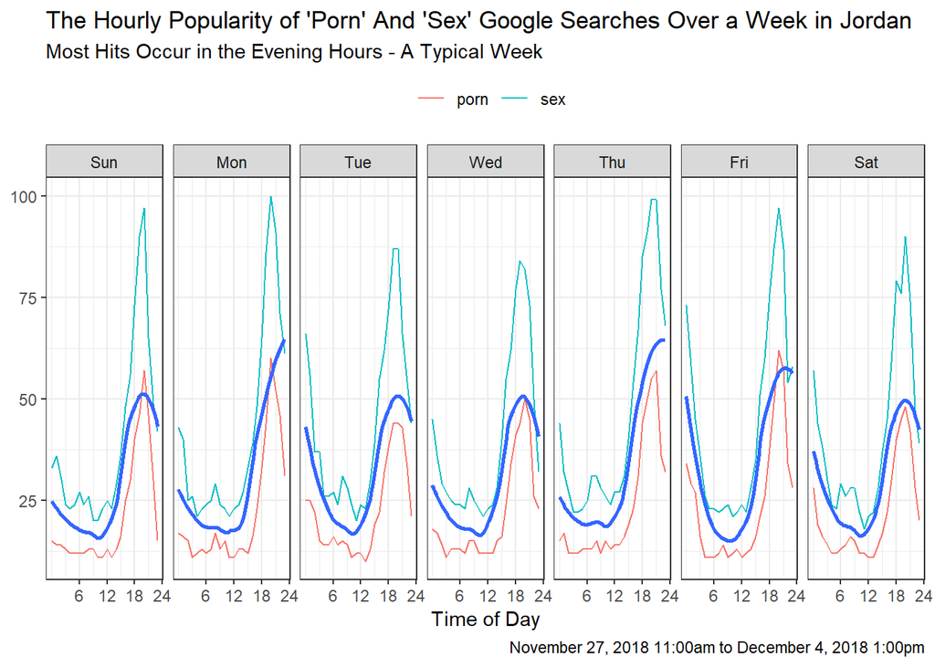

### Which Countries Exhibit the Most Significant Decrease in Pornography Searching?

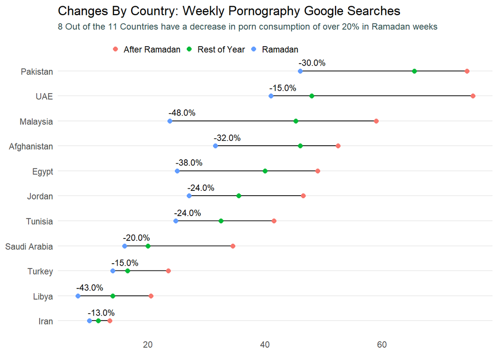

### Does Ramadan Impact Global Pornography Search Patterns?

**Global Level Changes in Sex and Porn Related Search Values Over Ramadan**

|  | *Dependent variable:* |
| --- | --- |
|  | Mean values for ‘sex’ and ‘porn’ hits by Week |
| Presence of Ram (0 or 1) | -1.145* |
|  | (0.688) |
| Constant | 87.500*** |
|  | (1.779) |
| Year Control? | Yes |
| Observations | 260 |
| R<sup>2</sup> | 0.293 |
| Adjusted R<sup>2</sup> | 0.276 |
| Residual Std. Error | 3.082 (df = 253) |
| F Statistic | 17.496*** (df = 6; 253) |
| *Note:* | p<0.1; p<0.05; p<0.01 |

### Future avenues for research

Next, I hope to study the relationship between country-level religious observance and decrease in pornography consumption over Ramadan. Does higher self-reported mosque attendance and religious belief result in a decrease in pornography searching over Ramadan of greater magnitude? I would like to find out.

#### *Hannah Hess, Harvard College 2019*. You can email me at hess@college.harvard.edu